# Module 2

Sri Seshadri

4/11/2018

I chose to look at the mean daily temperature of Fisher river at Dallas TX (https://datamarket.com/data/set/235d/mean-daily-temperature-fisher-river-near-dallas-jan-01-1988-to-dec-31-1991#!ds=235d&display=line)

As you can see the data is seasonal (yearly). I set the frequency to be at 365 days for the time series. The seasonal plot gives it away too.

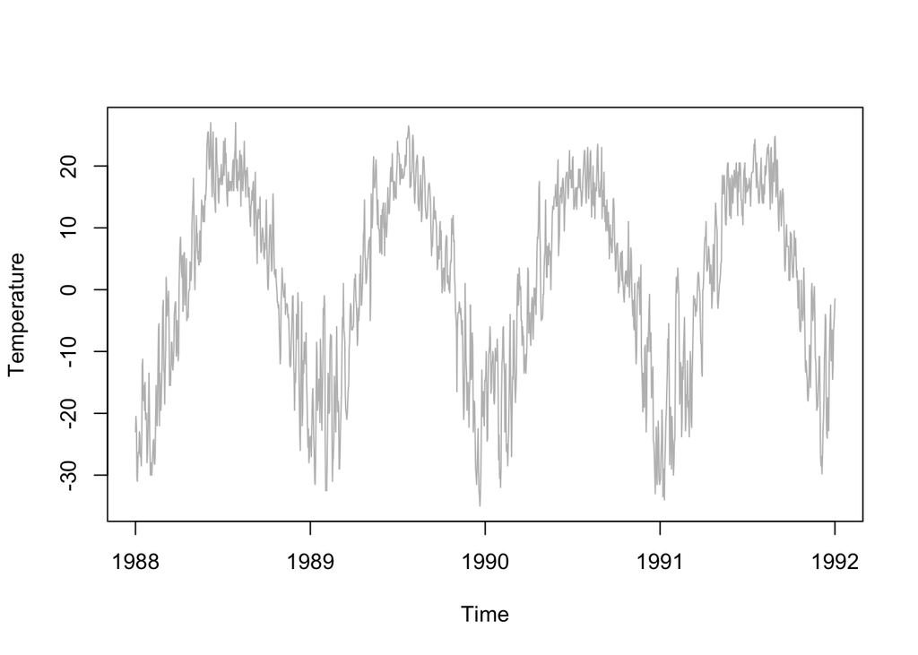

```r
library(lubridate)
MeanTemp <- readxl::read_xlsx("mean-daily-temperature-fisher-ri-2.xlsx")
Temperature <- ts(MeanTemp$Temp,start = decimal_date(MeanTemp$Time[1]), frequency = 365)
plot(Temperature,col = "grey")
```

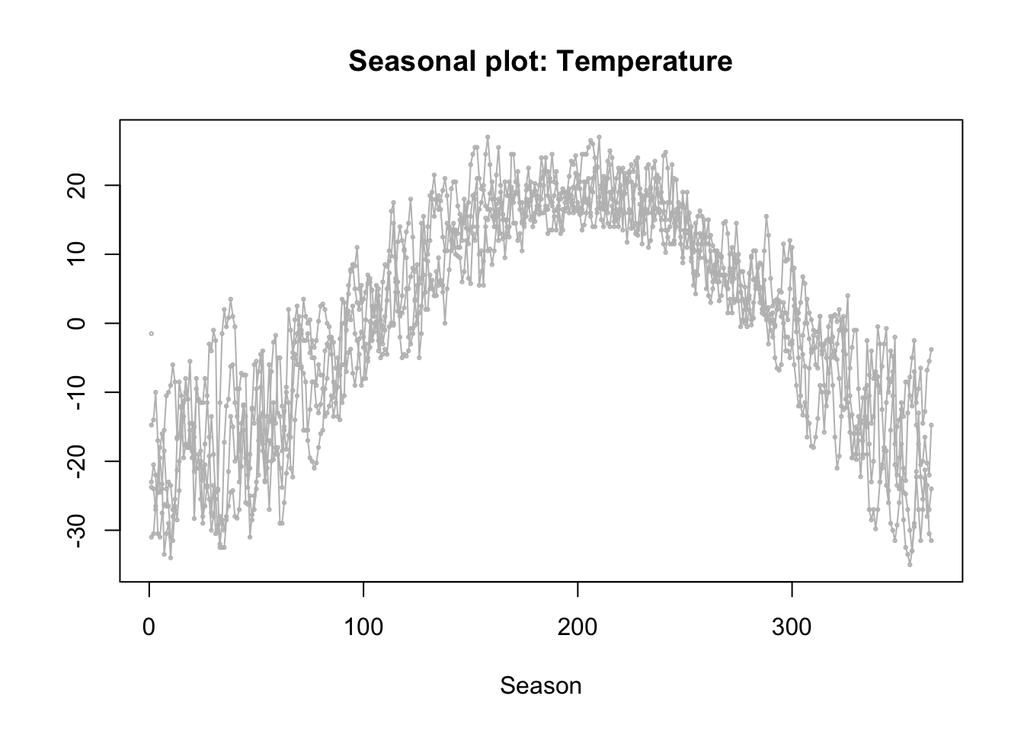

```r
seasonplot(Temperature,cex = 0.3,col = "grey")
```

# Decomposition

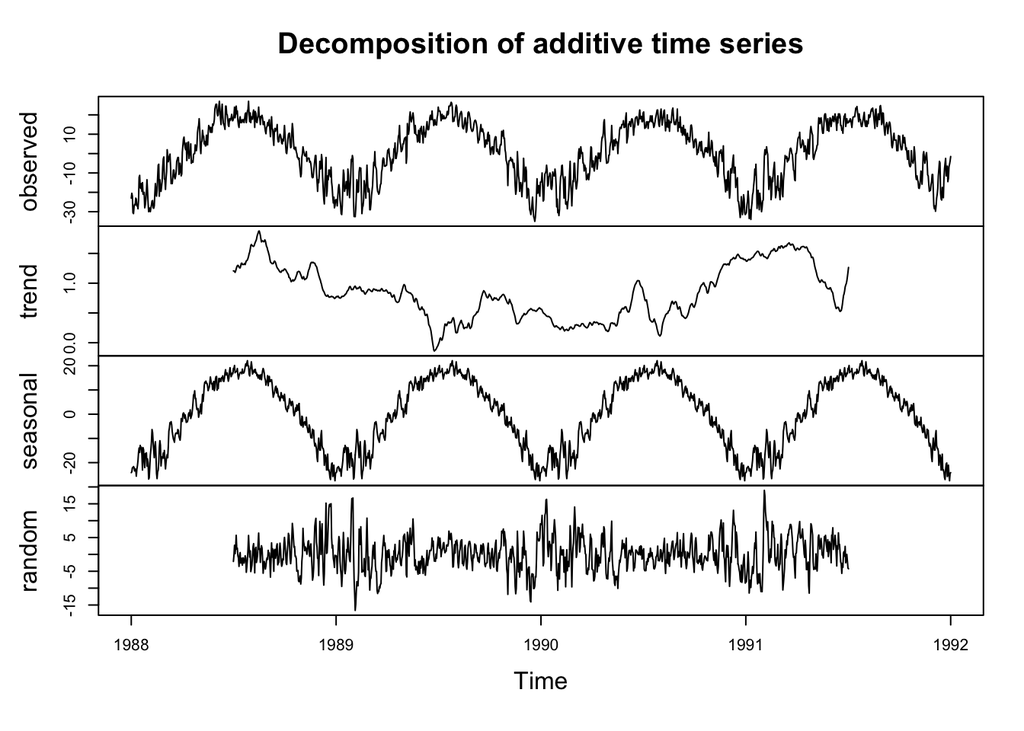

```r
plot(decompose(Temperature,type = "additive"))
```

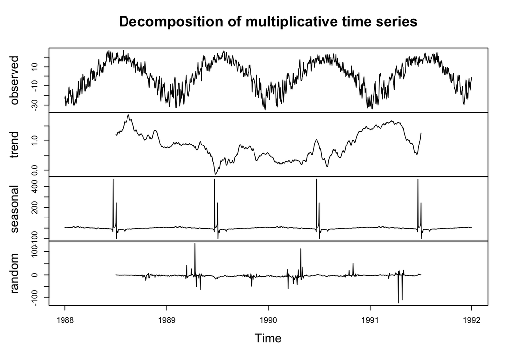

```r
plot(decompose(Temperature,type = "multiplicative"))
```

# Forecasting

## Classical decomposition’s drawback

While the classical decomposition is good, the moving averages employed in the decomposition makes us lose the forecasts for the inital half a year and the final half a year. Which is a big drawback. Hence cannot be used for forecasting. The classical decomposition is more for studying the data more so than prediction.

## STL - Seasonal trend decomposition using loess

I tried STL with a window of 10, 15 and 30. I am showing 30 here. May be I should split the data into training and test and do some kind of cross validation to choose the right t.window parameter. I am not sure, thoughts??

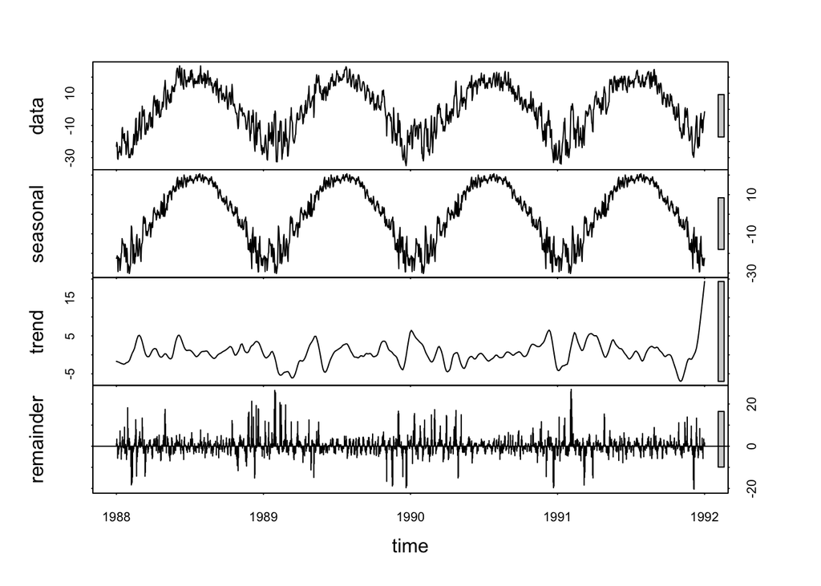

```r
stl.fit <- stl(x = Temperature,s.window = "periodic",t.window = 30,robust = T)
plot(stl.fit)
```

After seasonally adjusting the data, I tried to fit a seasonal naive model on the seasonally adjusted data. You can see there are some fluctuations at the begining of each year. This seasonal naive came out to be a better model.

As you can see from the plots below, the seasonal naive predictions on the seasonally adjusted data seems better than the out of the boc STL.

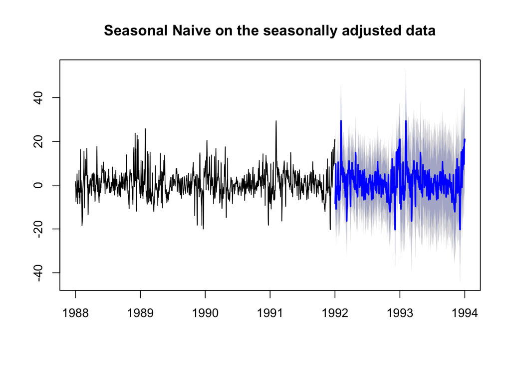

```r
seasonallyAdj <- forecast::seasadj(stl.fit)
plot(snaive(seasonallyAdj), main = "Seasonal Naive on the seasonally adjusted data")
```

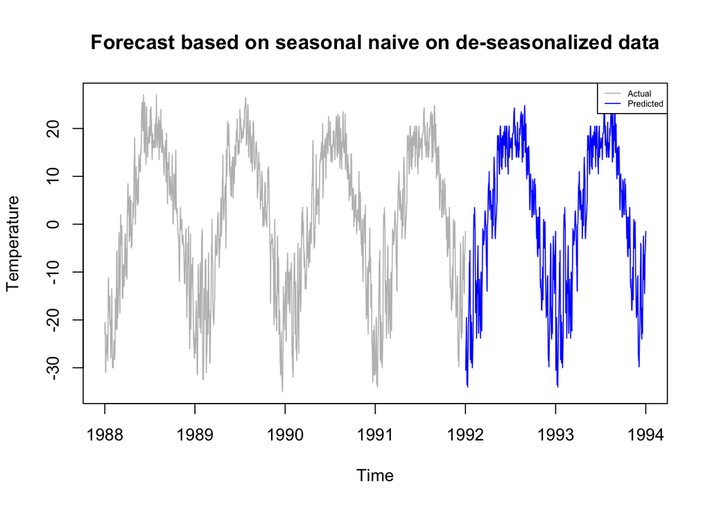

```r
seasonalDataFit <- snaive(stl.fit$time.series[,1],h = 365*2)
seasonallyAdjFit <- snaive(seasonallyAdj, h= 365*2)
fcts <- seasonallyAdjFit$mean + seasonalDataFit$mean
plot(Temperature,col = "grey",xlim = c(1988,1994), main = "Forecast based on seasonal naive on de-seasonalized data")
lines(fcts, col = "blue")
legend("topright", legend = c("Actual", "Predicted"), col = c("grey", "blue"),cex = 0.5, lty = 1)
```

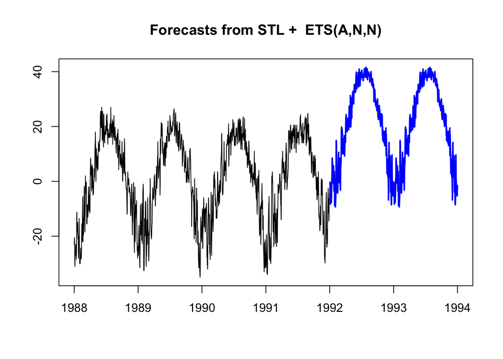

```r
forecasts <- forecast::forecast(stl.fit)
plot(forecasts,PI = F)
```

Your thoughts??

Sri